# Cicero (for Monocle 3)

元URL: https://cole-trapnell-lab.github.io/cicero-release/docs_m3/

- Ciceroは Monocleをベースにした scATAC-seq解析のRパッケージです。特に、ゲノム上のco-accessibilityを調べることによりゲノム中のcis-regulatory interactions（エンハンサープロモーター相互作用など）を予測することを目的としています。
- Ciceroの主な目的は、scATAC-seqデータを用いて、核内で物理的に近接している可能性が高いゲノム領域を予測することです。これは、エンハンサープロモーターペアを特定したり、ゲノム領域のシスアーキテクチャーの全体的な構造を把握するために使用されます。
- scATAC-seqデータは疎であるため、データ中の様々な技術的要因をロバストに補正するためには、類似性によって細胞を集約する必要があります（pseudo-buld）。
- Ciceroは、 "Cicero co-accessibility score"を提供します。これは-1～1の値をとり、ユーザが指定した距離以内に存在するピークペア各々に対して定義され、高い値ほど co-accessibilityが高いことを意味します。
- 細胞のクラスタリング、軌道解析、differential accessibility analysis も可能です。
- 現状ではmonocle2対応のものとmonocle3対応のものがあり、互換性がないので注意。ここではMonocle3ベースのCiceroを使います。

```r
### Installation
# BiocManager::install(c("Gviz", "GenomicRanges", "rtracklayer"))
# install.packages("devtools")
# devtools::install_github("cole-trapnell-lab/cicero-release", ref = "monocle3")

library(cicero)
```

## load data

- Ciceroは`CellDataSet (CDS)`オブジェクトにデータを保持します。このクラスはBioconductorにある `ExpressionSet`クラスから派生したもので、マイクロアレイ実験で用いられていた形式です。
- CDSオブジェクトの生成方法は [Monocle](http://cole-trapnell-lab.github.io/monocle-release/docs/#the-celldataset-class) を参照してください。
- CiceroではCDSオブジェクトの `fData`に遺伝子の代わりにピークを格納している。具体的には、`chr1_10390134_10391134` の形のピーク情報を必要とします。
- Ciceroの make_atac_cds 関数は入力としてdata.frameまたは sparse matrix形式のファイルへのパスを受け取ります。
- 具体的には、このファイルは3つの列を持つタブ区切りのテキストファイルでなければなりません。ファイルにはヘッダ行を持たないようにしてください。
  - 最初の列は、"chr10_100013372_100013596 "という形式のピーク座標
  - 2番目の列は細胞名
  - 3番目の列は、そのピークと重なる各細胞のリード数を表す整数です。

```r
# デモデータのロード
data(cicero_data)
input_cds <- make_atac_cds(cicero_data, binarize = TRUE)
```

## Constructing cis-regulatory networks

### Loading data from a simple sparse matrix format

```r
# download input data (take several minutes)
system("wget http://staff.washington.edu/hpliner/data/kidney_data.txt.gz")
```

```r
temp <- textConnection(readLines("kidney_data.txt.gz"))
cicero_data <- read.table(temp)
input_cds <- make_atac_cds(cicero_data, binarize = TRUE)
```

```r
set.seed(2017)
input_cds <- detect_genes(input_cds)
input_cds <- estimate_size_factors(input_cds)
input_cds <- preprocess_cds(input_cds, method = "LSI")
```

```r
# 次元削減
input_cds <- reduce_dimension(input_cds,
                              reduction_method = 'UMAP',
                              preprocess_method = "LSI")
```

```
No trajectory to plot. Has learn_graph() been called yet?

cluster not found in colData(cds), cells will not be colored

cluster_cells() has not been called yet, can't color cells by cluster
```

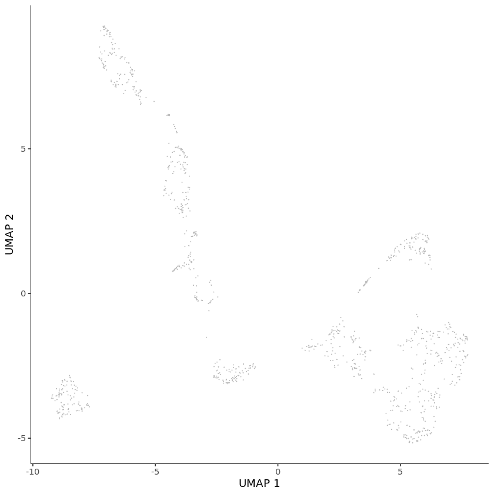

```r
plot_cells(input_cds)
```

```r
# access the UMAP coordinates from the input CDS object
# default parameterはhumanとmouseに合わせてあるので、他の生物種の場合はパラメータ変更を検討すること。
umap_coords <- reducedDims(input_cds)$UMAP
cicero_cds <- make_cicero_cds(input_cds, reduced_coordinates = umap_coords)
```

```
Overlap QC metrics:
Cells per bin: 50
Maximum shared cells bin-bin: 44
Mean shared cells bin-bin: 2.93496404725218
Median shared cells bin-bin: 0
```

- Cicero co-accessibility scoreを取得する最も簡単な方法は`run_cicero`を実行することです。
- `run_cicero`を実行するには、上記で作成したcicero CDSオブジェクトとゲノム座標ファイル(genome_table)が必要です。
  - run_ciceroの内部で実行される個々のコマンドを個別に呼び出すこともできます（元URL参照）。
- ヒトの hg19 座標とマウスの mm9 座標はパッケージに含まれており、data("human.hg19.genome")とdata("mouse.mm9.genome")でアクセスできます。ここでは、例のデータに続いて、呼び出し例を示します。

注意: デモの解析スピードを上げるために、ここでは2番染色体のごく一部だけでCiceroを実行しています。さらに、パラメータを計算するときに使用するサンプルウィンドウの数を2に設定しています - これは実際の解析ではもっと大きいはずです（デフォルトは100）。

```r
data("mouse.mm9.genome")
# use only a small part of the genome for speed
sample_genome <- subset(mouse.mm9.genome, V1 == "chr2")
sample_genome$V2[1] <- 10000000

## Usually use the whole mouse.mm9.genome ##
## Usually run with sample_num = 100 ##
conns <- run_cicero(cicero_cds, sample_genome, sample_num = 2)
```

```
[1] "Starting Cicero"
[1] "Calculating distance_parameter value"
[1] "Running models"
[1] "Assembling connections"
[1] "Successful cicero models:  29"
[1] "Other models: "

Zero or one element in range
                          11
[1] "Models with errors:  0"
[1] "Done"
```

```r
head(conns)
```

A data.frame: 6 × 3

|  | Peak1 <chr> | Peak2 <fct> | coaccess <dbl> |
| --- | --- | --- | --- |
| 1 | chr2_10001211_10002717 | chr2_9752799_9753235 | 0.00000000 |
| 2 | chr2_10001211_10002717 | chr2_9755255_9755584 | 0.04143003 |
| 3 | chr2_10001211_10002717 | chr2_9767538_9767832 | -0.08178246 |
| 4 | chr2_10001211_10002717 | chr2_9773328_9773904 | -0.13906733 |
| 5 | chr2_10001211_10002717 | chr2_9774059_9774511 | -0.26292558 |
| 6 | chr2_10001211_10002717 | chr2_9782941_9783191 | 0.20807063 |

### Visualizing Cicero Connections

- Ciceroには `plot_connections`と呼ばれる共同アクセシビリティを可視化するための一般的なプロット関数が含まれています。この関数はGvizフレームワークを使用して、ゲノムブラウザスタイルのプロットを行います。インタラクションの可視化には Sushi R を使います。
- `plot_connections`には多くのオプションがあり、いくつかは[Advanced Visualization](https://cole-trapnell-lab.github.io/cicero-release/docs_m3/#advanced-visualizaton)セクションで詳しく説明されています。
- 以下では、遺伝子もプロットできるように、オプションの gene_model データを入れています。

```r
# Download the GTF associated with this data (mm9) from ensembl and load it using rtracklayer

# download and unzip
temp <- tempfile()
download.file("ftp://ftp.ensembl.org/pub/release-65/gtf/mus_musculus/Mus_musculus.NCBIM37.65.gtf.gz", temp)
gene_anno <- rtracklayer::readGFF(temp)
unlink(temp)

# rename some columns to match requirements
gene_anno$chromosome <- paste0("chr", gene_anno$seqid)
gene_anno$gene <- gene_anno$gene_id
gene_anno$transcript <- gene_anno$transcript_id
gene_anno$symbol <- gene_anno$gene_name
```

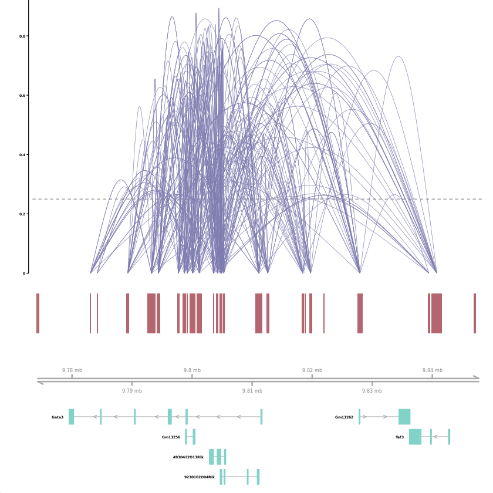

```r
plot_connections(conns, "chr2", 9773451, 9848598,
                 gene_model = gene_anno,
                 coaccess_cutoff = .25,
                 connection_width = .5,
                 collapseTranscripts = "longest" )
```

## Comparing Cicero connections to other datasets

- Ciceroで得られたインタラクションを他のアッセイで得られた類似のデータと比較することは有用である。
- 例えば、Ciceroの出力とChIA-PET dataを比較したい場合があります。
- これを行うために、Ciceroには `compare_connections` という関数があります。この関数は、接続ペアの`conns1`と`conns2`の2つのデータフレームを入力として取り、`conns1`から`conns2`で見つかった接続の論理ベクトルを返します。
- この関数での比較は`GenomicRanges`パッケージを使用して行われ、比較に傾きを許容するためにそのパッケージの`max_gap`引数を使用します。

例えば、Ciceroの予測値を(メークアップされた)ChIA-PET接続のセットと比較したい場合は、以下のように実行します。

```r
chia_conns <-  data.frame(Peak1 = c("chr2_3005100_3005200", "chr2_3004400_3004600",
                                    "chr2_3004900_3005100"),
                          Peak2 = c("chr2_3006400_3006600", "chr2_3006400_3006600",
                                    "chr2_3035100_3035200"))
head(chia_conns)
```

A data.frame: 3 × 2

|  | Peak1 <chr> | Peak2 <chr> |
| --- | --- | --- |
| 1 | chr2_3005100_3005200 | chr2_3006400_3006600 |
| 2 | chr2_3004400_3004600 | chr2_3006400_3006600 |
| 3 | chr2_3004900_3005100 | chr2_3035100_3035200 |

```r
conns$in_chia <- compare_connections(conns, chia_conns)

head(conns)
```

A data.frame: 6 × 4

|  | Peak1 <chr> | Peak2 <fct> | coaccess <dbl> | in_chia <lgl> |
| --- | --- | --- | --- | --- |
| 1 | chr2_10001211_10002717 | chr2_9752799_9753235 | 0.00000000 | FALSE |
| 2 | chr2_10001211_10002717 | chr2_9755255_9755584 | 0.04143003 | FALSE |
| 3 | chr2_10001211_10002717 | chr2_9767538_9767832 | -0.08178246 | FALSE |
| 4 | chr2_10001211_10002717 | chr2_9773328_9773904 | -0.13906733 | FALSE |
| 5 | chr2_10001211_10002717 | chr2_9774059_9774511 | -0.26292558 | FALSE |
| 6 | chr2_10001211_10002717 | chr2_9782941_9783191 | 0.20807063 | FALSE |

```r
conns$in_chia_100 <- compare_connections(conns, chia_conns, maxgap = 100)

head(conns)
```

A data.frame: 6 × 5

|  | Peak1 <chr> | Peak2 <fct> | coaccess <dbl> | in_chia <lgl> | in_chia_100 <lgl> |
| --- | --- | --- | --- | --- | --- |
| 1 | chr2_10001211_10002717 | chr2_9752799_9753235 | 0.00000000 | FALSE | FALSE |
| 2 | chr2_10001211_10002717 | chr2_9755255_9755584 | 0.04143003 | FALSE | FALSE |
| 3 | chr2_10001211_10002717 | chr2_9767538_9767832 | -0.08178246 | FALSE | FALSE |
| 4 | chr2_10001211_10002717 | chr2_9773328_9773904 | -0.13906733 | FALSE | FALSE |
| 5 | chr2_10001211_10002717 | chr2_9774059_9774511 | -0.26292558 | FALSE | FALSE |
| 6 | chr2_10001211_10002717 | chr2_9782941_9783191 | 0.20807063 | FALSE | FALSE |

- さらに、Ciceroのプロット機能には、データセットを視覚的に比較する方法があります。
- これを行うには、 `comparison_track` 引数を使用します。比較データフレームには、"coaccess"と呼ばれる最初の2つのピーク列を超えた3番目の列が含まれている必要があります。
  - これは、プロット関数がプロットされた接続の高さを決定する方法です。
  - これは、ChIA-PETのライゲーション数のような定量的な尺度であってもよいし、単に1の列であってもよい。
- プロットオプションの詳細は、マニュアルページの ?plot_connections と[Advanced Visualization](https://cole-trapnell-lab.github.io/cicero-release/docs_m3/#advanced-visualizaton)セクションを参照してください。

```r
# Add a column of 1s called "coaccess"
chia_conns <-  data.frame(Peak1 = c("chr2_3005100_3005200", "chr2_3004400_3004600", "chr2_3004900_3005100"),
                          Peak2 = c("chr2_3006400_3006600", "chr2_3006400_3006600", "chr2_3035100_3035200"),
                          coaccess = c(1, 1, 1))

plot_connections(conns, "chr2", 3004000, 3040000,
                 gene_model = gene_anno,
                 coaccess_cutoff = 0,
                 connection_width = .5,
                 comparison_track = chia_conns,
                 comparison_connection_width = .5,
                 nclude_axis_track = FALSE,
                 collapseTranscripts = "longest")
```

```
Error in plot_connections(conns, "chr2", 3004000, 3040000, gene_model = gene_anno, :  使われていない引数 (nclude_axis_track = FALSE)
Traceback:
```

以下略

## （参考）Loading 10X scATAC-seq data

以下は10Xのデータセットを用いて解析する場合のサンプルです。

```r
# read in matrix data using the Matrix package
indata <- Matrix::readMM("filtered_peak_bc_matrix/matrix.mtx")
# binarize the matrix
indata@x[indata@x > 0] <- 1

# format cell info
cellinfo <- read.table("filtered_peak_bc_matrix/barcodes.tsv")
row.names(cellinfo) <- cellinfo$V1
names(cellinfo) <- "cells"

# format peak info
peakinfo <- read.table("filtered_peak_bc_matrix/peaks.bed")
names(peakinfo) <- c("chr", "bp1", "bp2")
peakinfo$site_name <- paste(peakinfo$chr, peakinfo$bp1, peakinfo$bp2, sep="_")
row.names(peakinfo) <- peakinfo$site_name

row.names(indata) <- row.names(peakinfo)
colnames(indata) <- row.names(cellinfo)

# make CDS
input_cds <-  suppressWarnings(new_cell_data_set(indata,
cell_metadata = cellinfo,
gene_metadata = peakinfo))

input_cds <- monocle3::detect_genes(input_cds)

#Ensure there are no peaks included with zero reads
input_cds <- input_cds[Matrix::rowSums(exprs(input_cds)) != 0,]
```